# Exploratory Data Analysis

Eduardo Hidalgo

Diciembre 9, 2017

### Descripcion de las variables de la base original

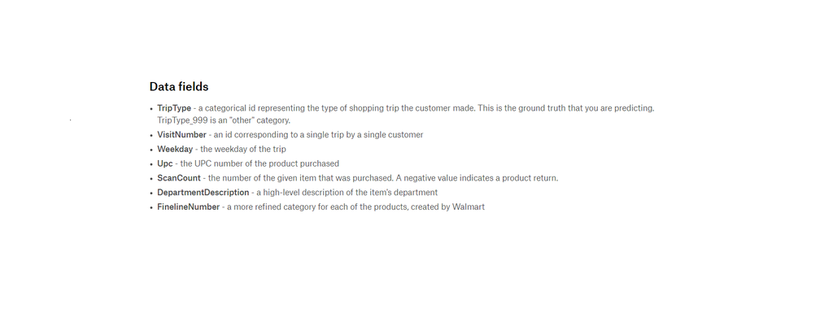

La base contiene 647,054 registros donde :

- Cada registro es un articulo comprado
- Cada compra se agrupa en una visita y la visita esta clasificada en un tipo de visita
- En cuanto a NA’s las variables Upc y FinelineNumber ambas cuentan con 4,129 observaciones de este tipo

```r
glimpse(train_set)
```

```
## Observations: 647,054
## Variables: 7
## $ TripType              <int> 999, 30, 30, 26, 26, 26, 26, 26, 26, 26,...
## $ VisitNumber           <int> 5, 7, 7, 8, 8, 8, 8, 8, 8, 8, 8, 8, 8, 8...
## $ Weekday               <chr> "Friday", "Friday", "Friday", "Friday", ...
## $ Upc                   <dbl> 68113152929, 60538815980, 7410811099, 22...
## $ ScanCount             <int> -1, 1, 1, 2, 2, 2, 1, 1, 1, -1, 1, 2, 1,...
## $ DepartmentDescription <chr> "FINANCIAL SERVICES", "SHOES", "PERSONAL...
## $ FinelineNumber        <int> 1000, 8931, 4504, 3565, 1017, 1017, 1017...
```

```r
summary(train_set)
```

```
##     TripType       VisitNumber       Weekday               Upc
##  Min.   :  3.00   Min.   :     5   Length:647054      Min.   :8.340e+02
##  1st Qu.: 27.00   1st Qu.: 49268   Class :character   1st Qu.:3.400e+09
##  Median : 39.00   Median : 97074   Mode  :character   Median :7.050e+09
##  Mean   : 58.58   Mean   : 96168                      Mean   :3.061e+10
##  3rd Qu.: 40.00   3rd Qu.:144316                      3rd Qu.:3.007e+10
##  Max.   :999.00   Max.   :191347                      Max.   :9.790e+11
##                                                       NA's   :4129
##    ScanCount       DepartmentDescription FinelineNumber
##  Min.   :-12.000   Length:647054         Min.   :   0
##  1st Qu.:  1.000   Class :character      1st Qu.:1404
##  Median :  1.000   Mode  :character      Median :3352
##  Mean   :  1.109                         Mean   :3727
##  3rd Qu.:  1.000                         3rd Qu.:5501
##  Max.   : 71.000                         Max.   :9998
##                                          NA's   :4129
```

Nota.- El objetivo del exámen es encontrar el mejor modelo para predecir el tipo de visita de acuerdo a las variables que más información aporten para la predicción del tipo de visita

Tratamiento de las variables

- Dia de la semana como factor
- Tipo de visita como factor
- Upc como factor
- ScanCount como factor
- FinelineNumber como factor

### Análisis univariado

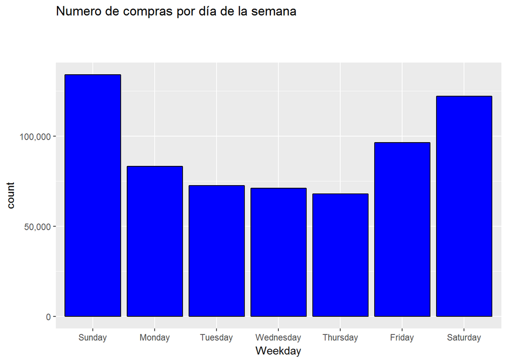

Los fines de semana son los días con maor numero de compras, visitas y articulos distintos comprados

Entre semana el día con mayor numero de compras, visitas y articulos distintos comprados es el Viernes

Resumen de Actividad por día de la semana

| Weekday | Compras | Visitas | Articulos |
| --- | --- | --- | --- |
| Sunday | 133,975 | 17,124 | 44,127 |
| Monday | 83,130 | 12,027 | 33,078 |
| Tuesday | 72,529 | 11,530 | 30,828 |
| Wednesday | 71,115 | 11,612 | 30,861 |
| Thursday | 67,962 | 11,243 | 30,762 |
| Friday | 96,247 | 15,234 | 38,124 |
| Saturday | 122,096 | 16,904 | 43,995 |

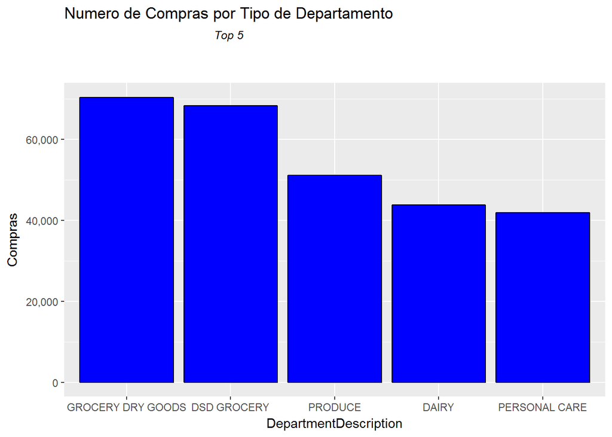

El ranking de los top 5 Departamentos con mayor numeor de compras es: **Grocery Dry Goods**,**DSD Grocery**,**Produce**,**Dairy**,**Personal Care**

Resumen de Actividad por tipo de departamento (Top 5)

| DepartmentDescription | Compras | Visitas | Articulos |
| --- | --- | --- | --- |
| GROCERY DRY GOODS | 70,402 | 21,502 | 7,577 |
| DSD GROCERY | 68,332 | 29,591 | 3,353 |
| PRODUCE | 51,115 | 18,727 | 1,037 |
| DAIRY | 43,820 | 17,927 | 1,568 |
| PERSONAL CARE | 41,969 | 17,864 | 4,704 |

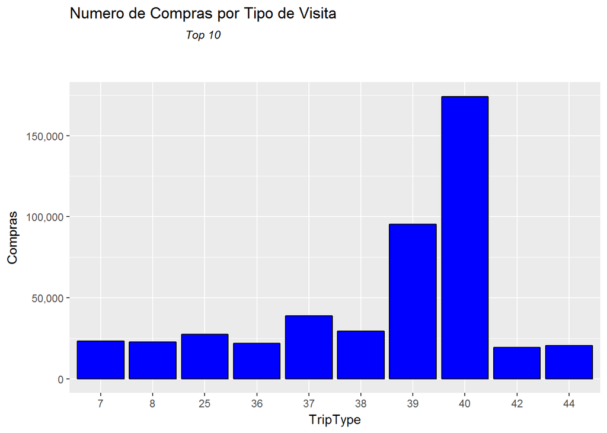

El tipo de visita **40** es el que tiene el mayor numero compras. Sin embargo, el tipo de visita **8** es el que tiene el mayor numero de Visitas registradas. Por último, el tipo de visita con el mayor numero de articulos distintos comprados es el **40**

| TripType | Compras | Visitas | Articulos |
| --- | --- | --- | --- |
| 40 | 174,164 | 6,130 | 38,404 |
| 39 | 95,504 | 9,896 | 31,178 |
| 37 | 38,954 | 2,788 | 12,039 |
| 38 | 29,565 | 2,912 | 10,718 |
| 25 | 27,609 | 3,698 | 19,261 |
| 7 | 23,199 | 5,752 | 8,105 |
| 8 | 22,844 | 12,161 | 9,854 |
| 36 | 21,990 | 3,005 | 11,530 |
| 44 | 20,424 | 1,187 | 14,846 |
| 42 | 19,468 | 1,858 | 14,794 |

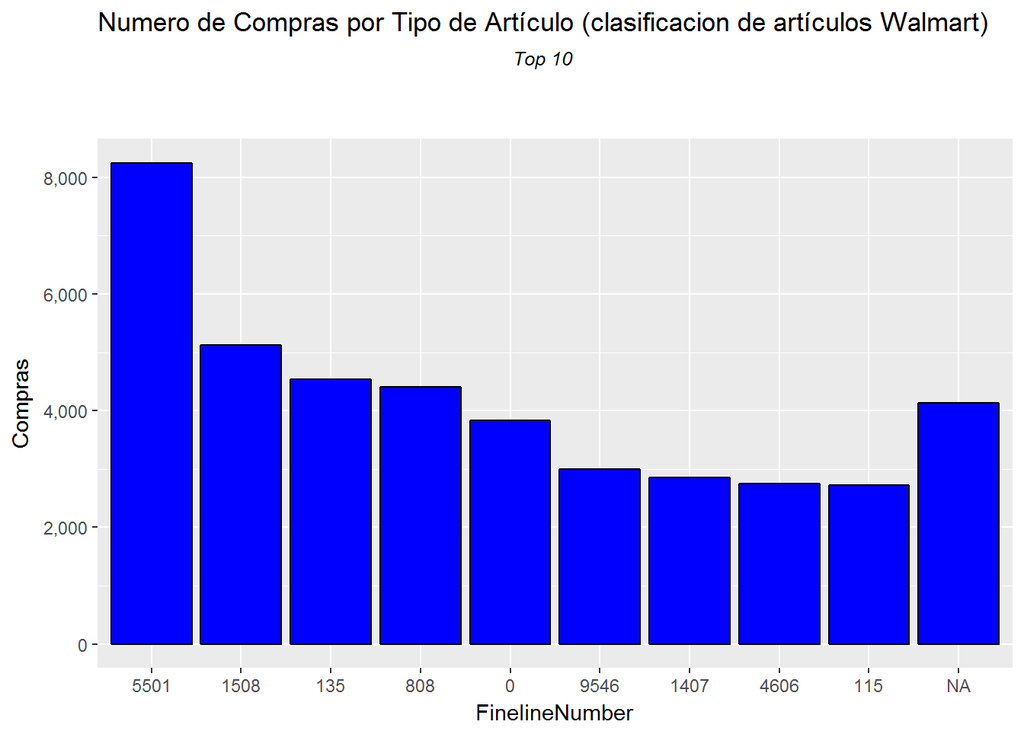

Walmart cuenta con una clasificacion más especifica para cada producto